# Esame fondamenti di scienza dei dati

Cristiano Roman

16/6/2021

## Introduzione

Dataset realizzato per trovare segnali correlati all’aumento dei **suicidi** a livello globale, dal 1985 al 2016. Si considerano due aspetti in particolare:

- *sociale*
- *economico*

```
## # A tibble: 6 x 12
##   country  year sex    age         suicides_no population `suicides/100k pop`
##   <chr>   <dbl> <chr>  <chr>             <dbl>      <dbl>               <dbl>
## 1 Albania  1987 male   15-24 years          21     312900                6.71
## 2 Albania  1987 male   35-54 years          16     308000                5.19
## 3 Albania  1987 female 15-24 years          14     289700                4.83
## 4 Albania  1987 male   75+ years             1      21800                4.59
## 5 Albania  1987 male   25-34 years           9     274300                3.28
## 6 Albania  1987 female 75+ years             1      35600                2.81
## # ... with 5 more variables: country-year <chr>, HDI for year <dbl>,
## #   gdp_for_year ($) <dbl>, gdp_per_capita ($) <dbl>, generation <chr>
```

### **variabili particolari**:

- **HDI**:
  - indicatore di sviluppo macroeconomico usato accanto al PIL dall’ ONU a partire dal 1993 per valutare la qualità della vita dei membri di un Paese.
  - da 0 a 1 e si suddivide in quattro gruppi: dai Paesi a sviluppo umano molto alto a quelli a basso sviluppo umano.
  - definito come la media geometrica di tre indici di base, legati rispettivamente alla speranza di vita, al livello di istruzione e al reddito
- **GDP**
  - Gross Domestic Product, significato equivalente al PIL italiano, ma tradotto in inglese [GDP](https://www.ecnews.it/gross-domestic-product-tradurre-pil-inglese/)
- **Generation**
  - G.I. Generation - nati nel 1901 - 1927
  - Silent - nati nel 1925 - 1942
  - Boomers - nati nel 1946 - 1964
  - Generation X - nati nel 1960 - 1980
  - Millennials - nati nel 1980 - 2000
  - Generation Z - nati a metà anni ’90 - inizi ’00

## Preprocessing del dataset

- L’indice di sviluppo umano (HDI) contiene molti valori di tipo *NA*

```
## [1] 19456
```

```
## [1] 27820
```

- eliminiamo la variabile *HDI* in quanto contiene quasi 20000 dati *NA* su 27820, corrispondenti a circa 2/3 delle osservazioni totali,rendendola così inutilizzabile
- eliminiamo i dati del 2016 poichè sono stati analizzati pochi stati
- aggiungiamo la variabile *continent* con i relativi dati associati agli stati attraverso la libreria [*countrycode*](https://cran.r-project.org/web/packages/countrycode/countrycode.pdf)
- rinominiamo alcune variabili
- escludiamo gli stati con meno di 3 anni di dati a disposizione

```
## # A tibble: 6 x 12
##   country  year sex    age     suicides population `suicides/100k ~ country_year
##   <chr>   <dbl> <chr>  <ord>      <dbl>      <dbl>            <dbl> <chr>
## 1 Albania  1987 male   15-24 ~       21     312900             6.71 Albania1987
## 2 Albania  1987 male   35-54 ~       16     308000             5.19 Albania1987
## 3 Albania  1987 female 15-24 ~       14     289700             4.83 Albania1987
## 4 Albania  1987 male   75+ ye~        1      21800             4.59 Albania1987
## 5 Albania  1987 male   25-34 ~        9     274300             3.28 Albania1987
## 6 Albania  1987 female 75+ ye~        1      35600             2.81 Albania1987
## # ... with 4 more variables: gdp_for_year <dbl>, gdp_per_capita <dbl>,
## #   generation <chr>, continent <chr>
```

```
##    country               year          sex                     age
##  Length:27645       Min.   :1985   Length:27645       5-14 years :4607
##  Class :character   1st Qu.:1994   Class :character   15-24 years:4605
##  Mode  :character   Median :2002   Mode  :character   25-34 years:4609
##                     Mean   :2001                      35-54 years:4610
##                     3rd Qu.:2008                      55-74 years:4608
##                     Max.   :2015                      75+ years  :4606
##     suicides         population       suicides/100k pop country_year
##  Min.   :    0.0   Min.   :     278   Min.   :  0.00    Length:27645
##  1st Qu.:    3.0   1st Qu.:   97682   1st Qu.:  0.91    Class :character
##  Median :   25.0   Median :  431400   Median :  5.98    Mode  :character
##  Mean   :  243.5   Mean   : 1851634   Mean   : 12.82
##  3rd Qu.:  132.0   3rd Qu.: 1491923   3rd Qu.: 16.61
##  Max.   :22338.0   Max.   :43805214   Max.   :224.97
##   gdp_for_year       gdp_per_capita    generation         continent
##  Min.   :4.692e+07   Min.   :   251   Length:27645       Length:27645
##  1st Qu.:8.976e+09   1st Qu.:  3436   Class :character   Class :character
##  Median :4.811e+10   Median :  9283   Mode  :character   Mode  :character
##  Mean   :4.473e+11   Mean   : 16821
##  3rd Qu.:2.606e+11   3rd Qu.: 24870
##  Max.   :1.812e+13   Max.   :126352
```

## Variazione GDP dal 1985 al 2015

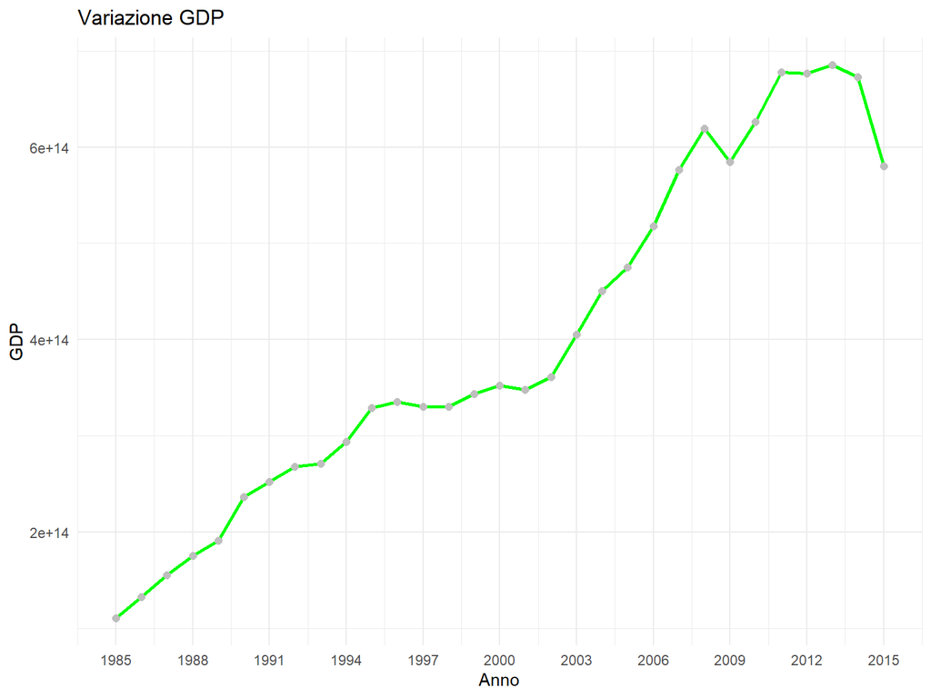

- è evidente la correlazione fra il GDP totale e gli anni

```
## [1] 0.9739896
```

## Suicidi dal 1985 al 2015

- l’**eutanasia** non viene valutata come suicidio,in quanto è considerata principalmente una procedura medica.
- nel *Mondo*

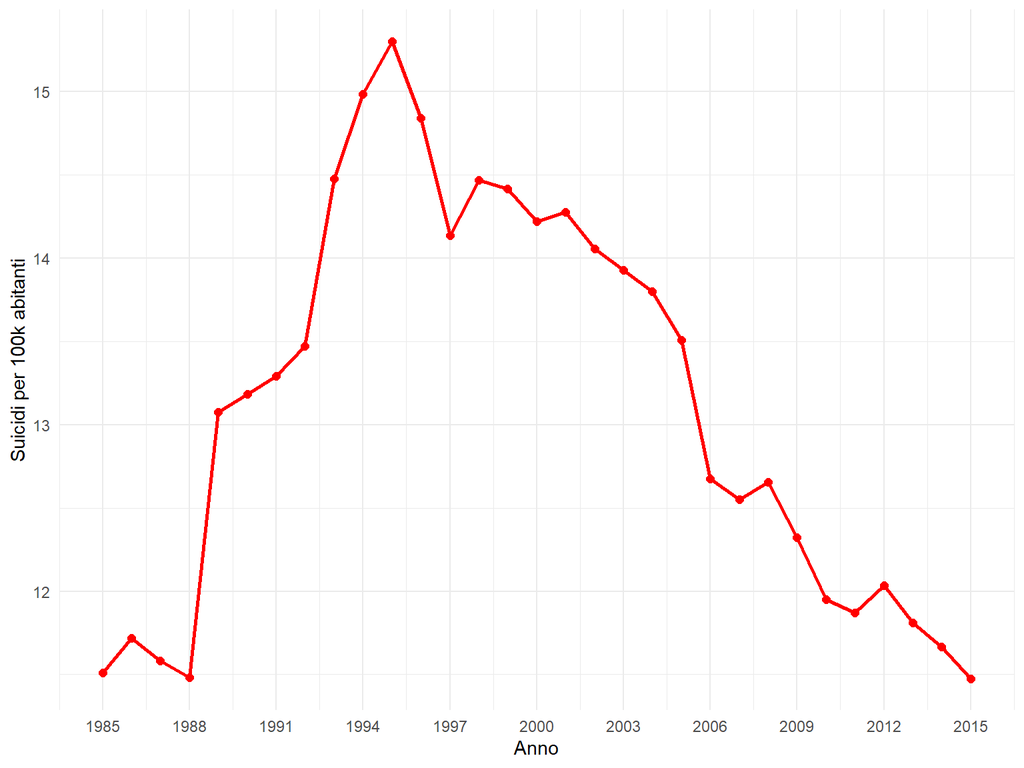

- In corrispondenza della **crisi economico-finanziaria** del 2008 è stato documentato un aumento dei suicidi in molti Paesi; in Italia, tale aumento si è protratto anche negli anni seguenti
- in *Italia*

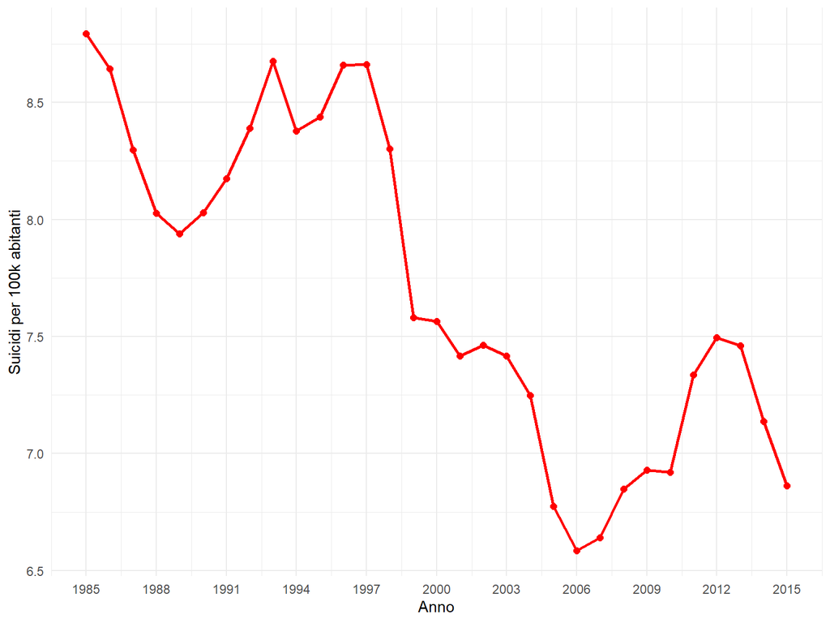

## Suicidi per continente

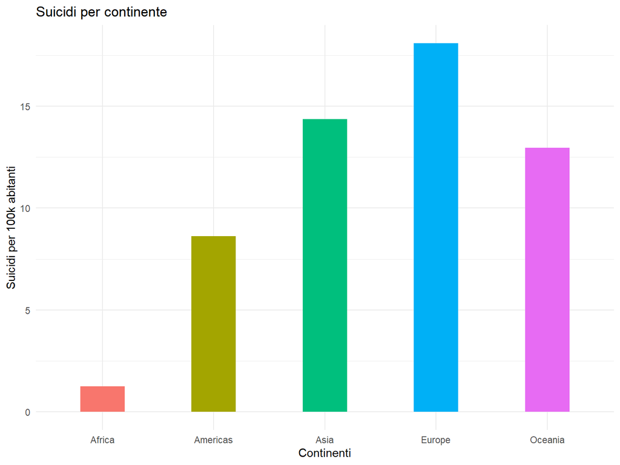

- l’Africa ha un indice così basso perchè non è stato analizzato un numero sufficiente di stati

```
## # A tibble: 4 x 2
##   country      righe
##   <chr>        <int>
## 1 Cabo Verde       9
## 2 Mauritius      372
## 3 Seychelles     216
## 4 South Africa   240
```

- l’Europa pur non essendo il continente più popolato è quello con un maggior numero di suicidi

## Suicidi per stato

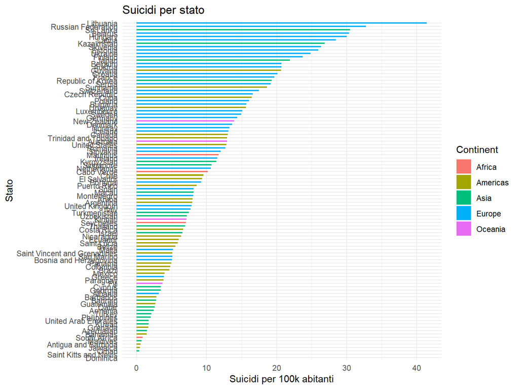

## Suicidi per età

- Il tasso di suicidio è più elevato tra gli anziani, ma è tra i giovani che il suicidio rappresenta la percentuale più importante sul totale dei decessi; in Italia, così come nel resto del mondo, il suicidio è la terza più frequente causa di morte tra le persone di 15-34 anni.
- nel *Mondo*

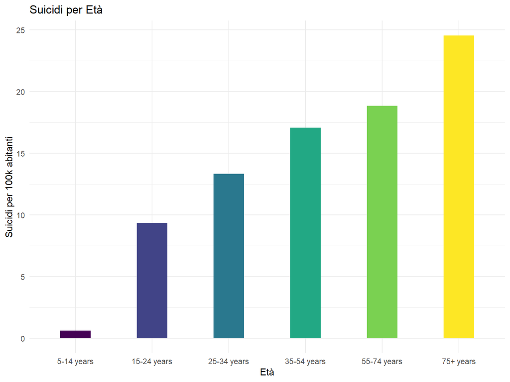

- in *Italia*

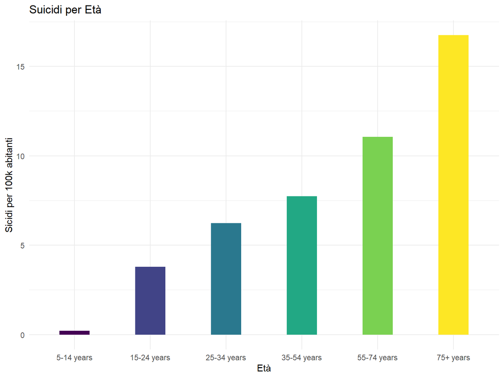

## Età suicidi per continente

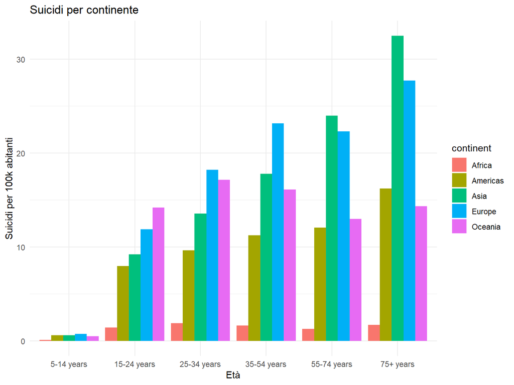

## Suicidi per genere

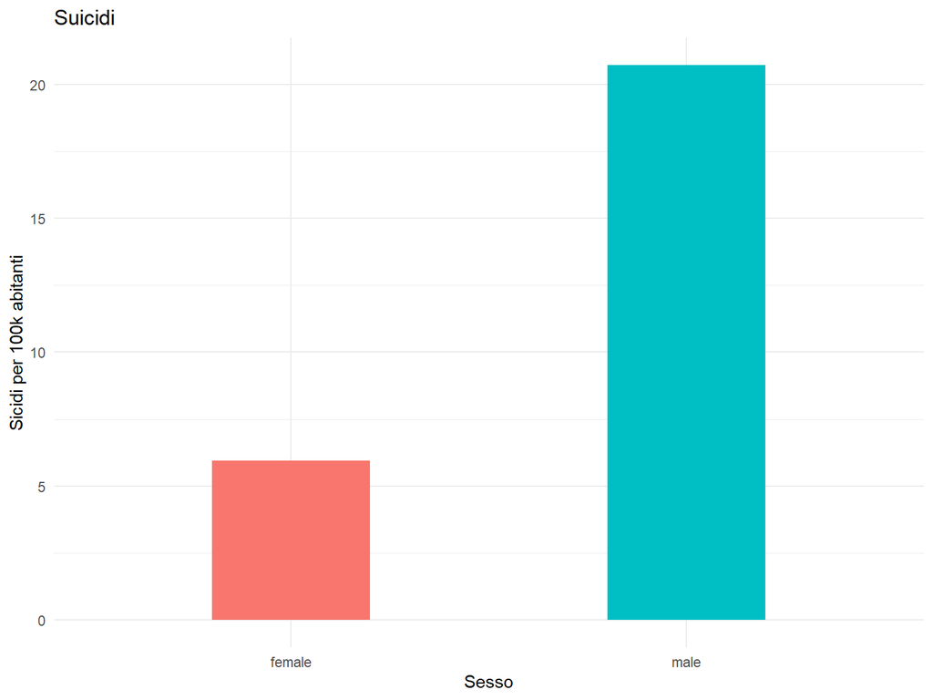

- gli uomini hanno un tasso di suicidio circa quattro volte superiore alle donne,tuttavia è affermato che le donne tentano il suicidio più spesso rispetto agli uomini perché diagnosticate come affette da depressione.
- è stato riscontrato che i fattori di rischio come disoccupazione, pensionamento e l’essere single sono tutti fattori di rischio significativi per il suicidio degli uomini, mentre sono molto meno significativi nelle donne.

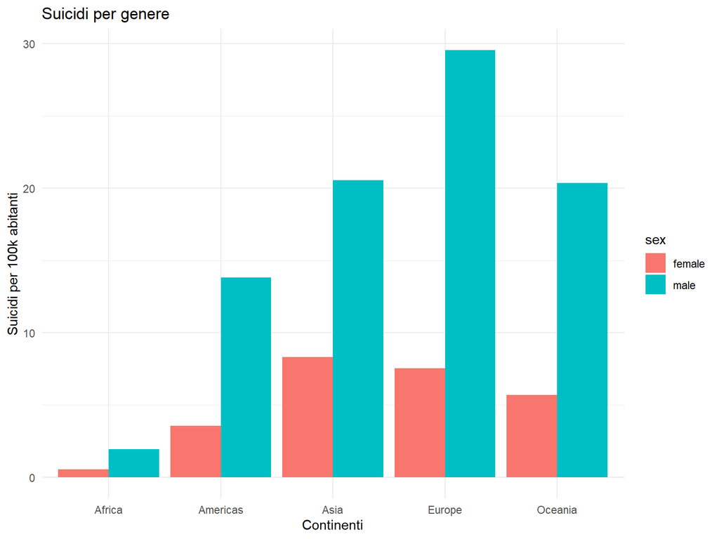

## Rapporto fra ricchezza di uno stato e suicidi

- All’aumentare della ricchezza di uno stato il suo numero di suicidi cresce o diminuisce?

```
## # A tibble: 1 x 1
##   cor_med
##     <dbl>
## 1   0.880
```

- il risultato conferma l’ipotesi in quanto c’è una forte correlazione (0.880) fra il *gdp pro capite* e lo scorrere gli *anni*,che presuppongono lo sviluppo economico di ogni stato.

## Numero di suicidi per stato rispetto al GDP

- Gli stati più ricchi hanno un numero di suicidi maggiore ?

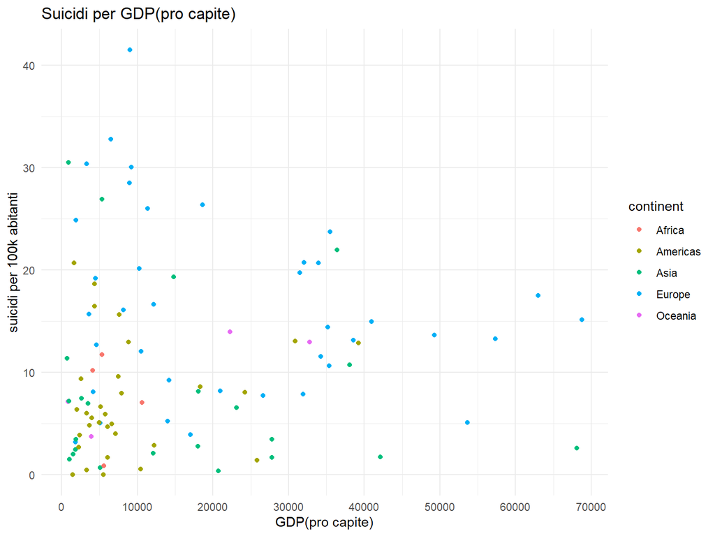

- si nota qualche valore residuo con un impatto significativo nello studio del modello
- visualizziamo gli *outliers* attraverso un boxplot

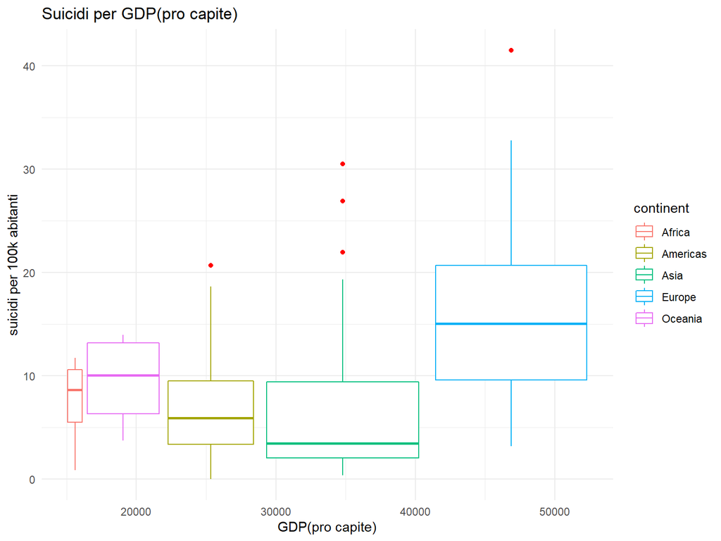

- analizziamo il modello con gli *outliers*

```
##
## Call:
## lm(formula = suicidi_per_100k ~ gdp_per_capita, data = gdp_continent)
##
## Residuals:
##     Min      1Q  Median      3Q     Max
## -10.771  -6.632  -2.578   4.750  30.791
##
## Coefficients:
##                 Estimate Std. Error t value Pr(>|t|)
## (Intercept)    1.032e+01  1.228e+00   8.401 3.52e-13 ***
## gdp_per_capita 3.969e-05  5.369e-05   0.739    0.462
## ---
## Signif. codes:  0 '***' 0.001 '**' 0.01 '*' 0.05 '.' 0.1 ' ' 1
##
## Residual standard error: 8.763 on 98 degrees of freedom
## Multiple R-squared:  0.005545,   Adjusted R-squared:  -0.004603
## F-statistic: 0.5464 on 1 and 98 DF,  p-value: 0.4616
```

- il valore del coefficiente di determinazione **R<sup>2</sup>** è molto basso (0.006),il che significa che la varibile esplicativa *Gdp_per_capita* non spiega in maniera ottimale la variabile riposta *suicidi_per_100k*,inoltre il *p-value* è molto maggiore rispetto alla soglia minima per il rifiuto dell’ipotesi nulla (0.05).
- eliminiamo gli *outliers*

```
##
## Call:
## lm(formula = suicidi_per_100k ~ gdp_per_capita, data = gdp_continent_no_outliers)
##
## Residuals:
##     Min      1Q  Median      3Q     Max
## -11.119  -5.128  -1.498   3.045  20.646
##
## Coefficients:
##                 Estimate Std. Error t value Pr(>|t|)
## (Intercept)    8.410e+00  1.073e+00   7.841 7.26e-12 ***
## gdp_per_capita 1.047e-04  4.795e-05   2.183   0.0316 *
## ---
## Signif. codes:  0 '***' 0.001 '**' 0.01 '*' 0.05 '.' 0.1 ' ' 1
##
## Residual standard error: 7.334 on 93 degrees of freedom
## Multiple R-squared:  0.04873,    Adjusted R-squared:  0.0385
## F-statistic: 4.764 on 1 and 93 DF,  p-value: 0.03159
```

- il *coefficiente di determinazione* è più alto ma non è sufficiente a rendere affidabile il modello. Tuttavia il *p-value* (0.03) è minore rispetto alla soglia tipica (0.05) di rifiuto dell’ipotesi nulla, e quindi possiamo rifiutare l’ipotesi nulla tale per cui il Gdp di una nazione non è in relazione con il tasso di suicidi
- visualizziamo il grafico corretto

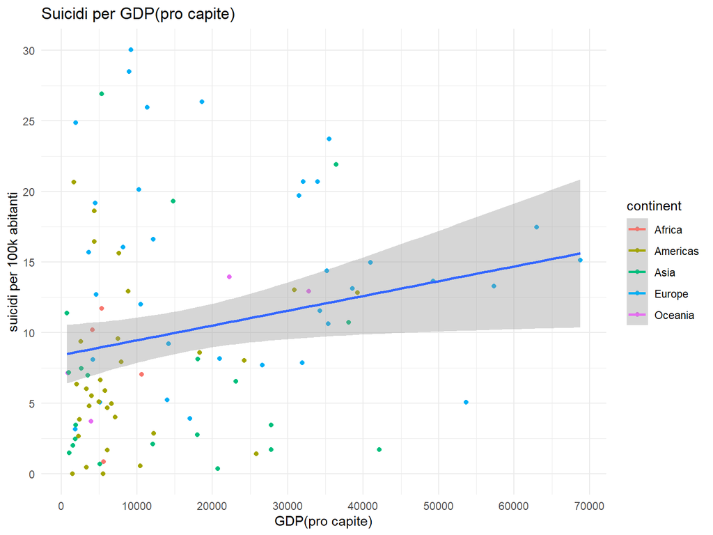

## Suicidi in relazione a genere e GDP pro capite

- Come varia il tasso di suicidi fra uomini e donne in relazione al GDP pro capite?

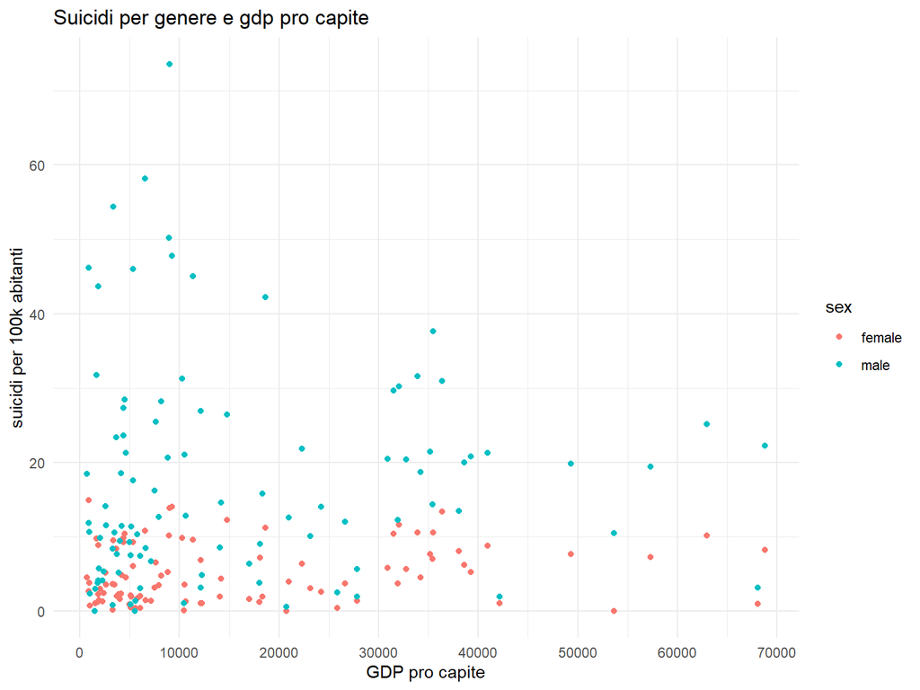

- visualizziamo gli *outliers*

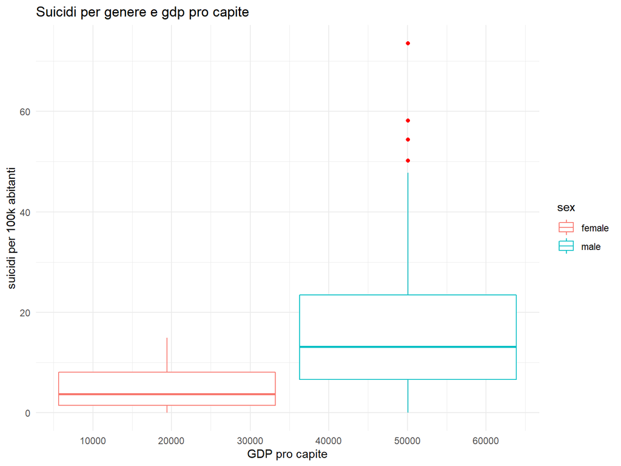

- analizziamo il modello con *outliers*

```
##
## Call:
## lm(formula = suicidi_per_100k ~ sex, data = gdp_sex)
##
## Residuals:
##     Min      1Q  Median      3Q     Max
## -17.376  -4.897  -1.509   3.971  56.168
##
## Coefficients:
##             Estimate Std. Error t value Pr(>|t|)
## (Intercept)    4.897      1.068   4.586 8.02e-06 ***
## sexmale       12.479      1.510   8.263 2.01e-14 ***
## ---
## Signif. codes:  0 '***' 0.001 '**' 0.01 '*' 0.05 '.' 0.1 ' ' 1
##
## Residual standard error: 10.68 on 198 degrees of freedom
## Multiple R-squared:  0.2564, Adjusted R-squared:  0.2527
## F-statistic: 68.28 on 1 and 198 DF,  p-value: 2.014e-14
```

- cancelliamo gli *outliers* dal modello

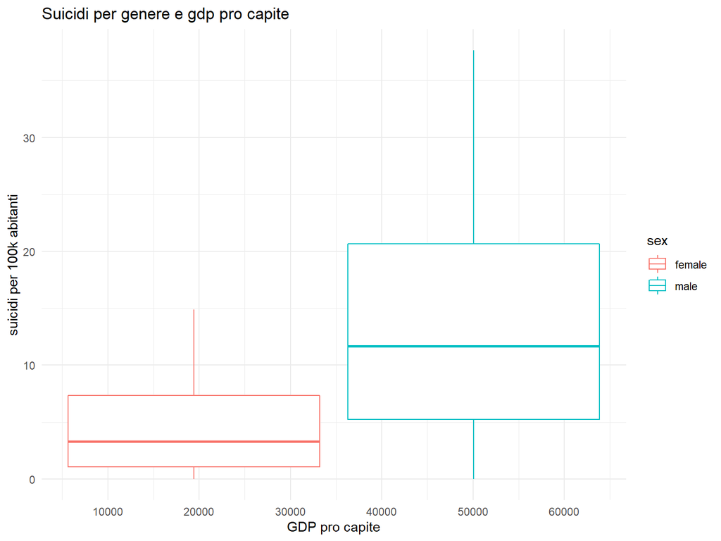

- visualizziamo il grafico senza *outliers*

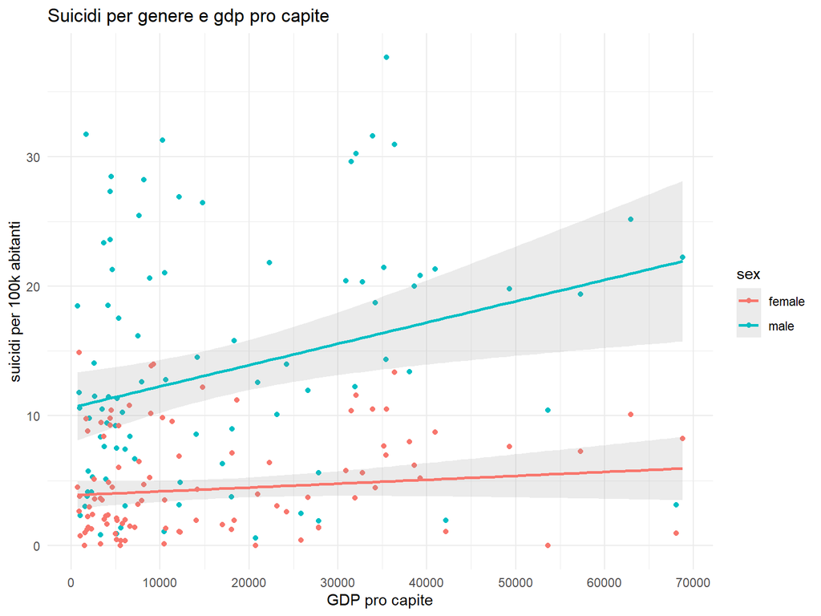

- analizziamo il modello corretto

[output not shown]

- con un **R^2** pari a *0.3* questo modello è abbastanza affidabile e ha un discreto potere predittivo per quanto riguarda la variabile risposta *suicidi_per_100k* rispetto alla variabile esplicativa *sex*.
- possiamo concludere che per gli uomini al crescere del *GDP pro capite* cresce il tasso di suicidi,mentre le donne qualunque sia il valore del *GDP pro capite* hanno un tasso di suicidi per lo più costante, nettamente più basso rispetto a quello degli uomini
- il tasso di suicidi per motivi economici è in parte legato alla pressione maschile a mantenere la famiglia, che in passato era addirittura legge (obbligo del marito a mantenere la moglie).

## Suicidi rispetto alla generazione di nascita

- Come varia l’andamento dei suicidi per i vari tipi di generazione nel tempo?

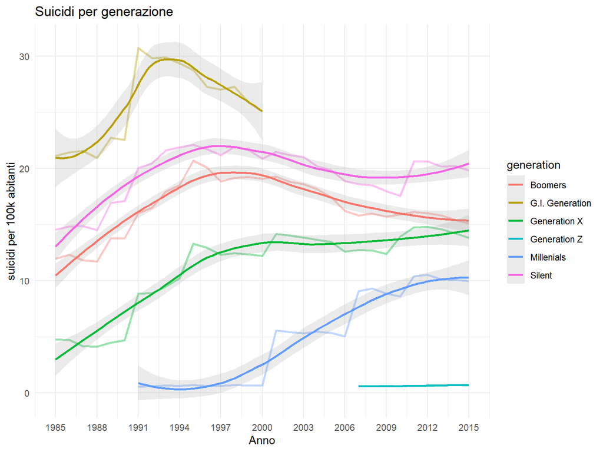

## Suicidi rispetto all’età

- Come varia il numero di suicidi per età comprese fra i 5 e 75+ anni ?

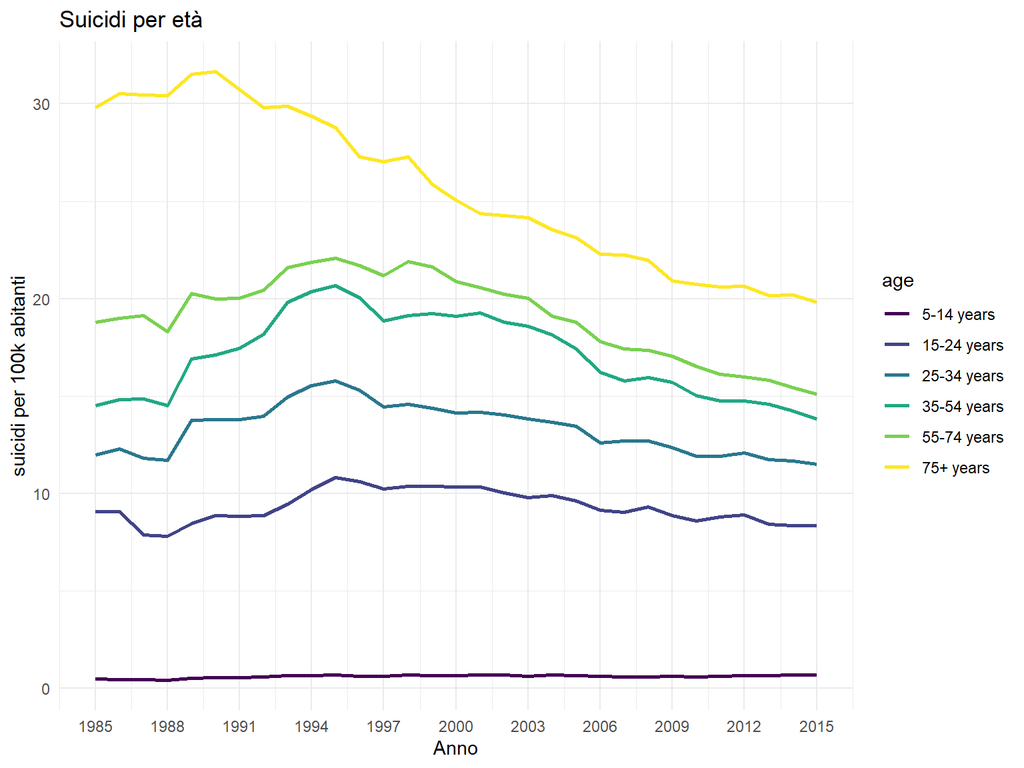

- il trend delle curve è in discesa per quasi tutte le categorie di età, il che significa che con gli anni il numero di suicidi continua a diminuire,soprattutto per la categoria degli *over 75*. La curva dei suicidi per le persone con età da 15 a 24 anni ha un andamento costante.

## Suicidi per continente

- Come varia il numero di suicidi nei vari continenti?

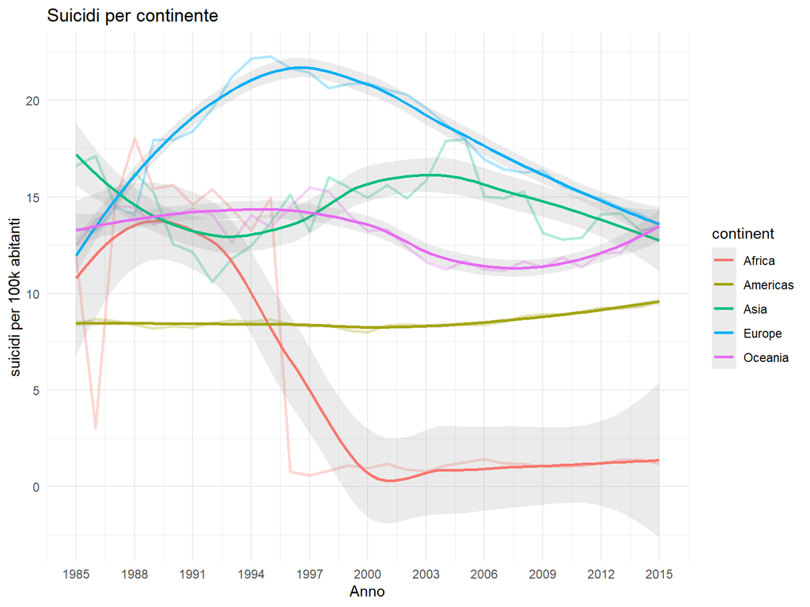

- in *Europa,Asia e Africa*, il numero di suicidi è in calo, mentre in *America e Oceania* è in leggera crescita.

## In conclusione

- C’è effettivamente una buona correlazione fra i *suicidi per 100k* e le variabili *gdp pro capite*,*year*,*sex* ?

```
##
## Call:
## lm(formula = suicidi_per_100k ~ gdp_per_capita + sex, data = gdp_anni)
##
## Residuals:
##     Min      1Q  Median      3Q     Max
## -4.4557 -0.3626 -0.0241  0.2008  3.5628
##
## Coefficients:
##                  Estimate Std. Error t value Pr(>|t|)
## (Intercept)     7.155e+00  5.459e-01  13.107   <2e-16 ***
## gdp_per_capita -7.219e-05  2.896e-05  -2.493   0.0155 *
## sexmale         1.461e+01  4.011e-01  36.417   <2e-16 ***
## ---
## Signif. codes:  0 '***' 0.001 '**' 0.01 '*' 0.05 '.' 0.1 ' ' 1
##
## Residual standard error: 1.579 on 59 degrees of freedom
## Multiple R-squared:  0.9576, Adjusted R-squared:  0.9562
## F-statistic: 666.2 on 2 and 59 DF,  p-value: < 2.2e-16
```

[figure not shown]

**FINE PRESENTAZIONE**